# Лабораторная работа 3

Четвергов Матвей, номер 27 (варианты 4, 13)

*trades.RData* Файл содержит данные Евростата о импорте и экспорте товаров партнеров Евросоюза (значения указаны в Евро).

### Задание 1.

4. *trades.RData* Объедините таблицы в одну, уберите столбец с территорией торговли, т.к. там только Евросоюз, оставим только строки с экспортом и импортом, вынесете данные по экспорту и импорту в отдельные переменные. Постройте линейный график изменения суммарных величин импорта и экспорта по импорту/экспорту продуктов питания, напитков и табака (у вас должно получиться 2 графика на одном изображении). Используйте цвет для разделения графиков. Добавьте текстовые подписи величин импорта и экспорта. Отрегулируйте местоположение и размер шрифта для подписей так, чтобы они не налезали на линии и не перекрывали друг друга, рисунок был максимально наглядным. Придумайте новые названия для графика и осей.

```r
install.packages("dplyr")
install.packages("tidyr")
install.packages("ggplot2")
```

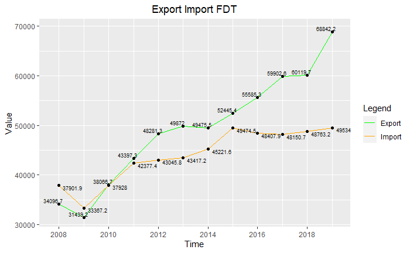

```r
library(dplyr, warn.conflicts = FALSE)
library(stringr)
library(tidyr)
library(ggplot2)
load("C:/Users/79130/Desktop/trades.RData")

tb <- trades |>
    bind_rows() |> # объединим прочитанные таблицы в одну
    select(-geo) |> # убираем столбец с территорией торговли, т.к. там только Евросоюз
    dplyr::filter(str_detect(indic_et, "Exports in|Imports in")) |> # оставим только экспорт и импорт
    pivot_wider(names_from = indic_et, values_from = values) |> # вынесем данные по экспорту и импорту в отдельные переменные
    rename(
        export = "Exports in million of ECU/EURO",
        import = "Imports in million of ECU/EURO"
    ) # дадим им краткие названия

trades_fdt <- tb |>
    dplyr::filter(str_detect(sitc06, "Food, drinks and tobacco")) |>
    group_by(time) |>
    summarise(export = sum(export), import = sum(import))

colors <- c("Export" = "green", "Import" = "orange")
graphic <- ggplot(trades_fdt, aes(x = time))
graphic <- graphic + geom_line(aes(y = export, color = "Export")) + geom_point(aes(y = export))
graphic <- graphic + geom_line(aes(y = import, color = "Import")) + geom_point(aes(y = import))
graphic <- graphic + geom_text(aes(y = export, label = export), nudge_x = -80, nudge_y = 700, size=2.5) + geom_text(aes(y = import, label = import),hjust = 0,nudge_x = 60,  nudge_y = -400, size=2.5)
graphic <- graphic + labs(x = "Time", y = "Value", title = "Export Import FDT", color = "Legend") + scale_color_manual(values = colors)
graphic <- graphic + theme(plot.title = element_text(hjust = 0.5))
print(graphic)
```

### Задание 2.

13. *data2.csv, data1.txt* Объедините data.frames по идентификаторам сортов. Исключите те сорта, для которых есть пропущенные значения. Выбрать одну количественную и две качественные переменные . Разбить значения количественной переменной на группы в соответствии со значениями одной из качественных переменных. Нарисовать график, на котором отображены плотности распределений и гистограммы для получившихся групп, обозначить разные группы разными цветами.

```r
install.packages("hrbrthemes")
install.packages("gridExtra")
```

```r
library(tidyr)
library(ggplot2)
library(dplyr)
library(hrbrthemes)
library(gridExtra)

dataframe1 <- read.csv("C:/Users/79130/Desktop/data1.txt", sep=" ", skip=1)
rownames(dataframe1) <- dataframe1$X1
dataframe1 <- subset(dataframe1, select=-c(X1))

dataframe2 <- read.csv("C:/Users/79130/Desktop/data2.csv", sep=',', header=FALSE)
dataframe2 <- data.frame(t(dataframe2))
names(dataframe2) <- dataframe2[1, ]
dataframe2 <- dataframe2[-1, ]
names(dataframe2)[1] = "Sample"

dataframe <- merge(dataframe1,dataframe2,by="Sample") %>% select(-c(Sample))
dataframe
```

| Height | Protein | Oil | GrowthType | Polegaemost | GenmBMatur | MaturType |
| --- | --- | --- | --- | --- | --- | --- |
| 92.5 | 39.8 | 16.5 | 0 | 1 | 123 | 5 |
| 155.0 | NA | NA | 0 | 1 | 143 | 6 |
| 105.0 | NA | NA | 0 | 1 | 143 | 6 |
| 62.5 | 41.8 | 20.9 | 1 | 0 | 95 | 2 |
| 42.5 | 40.7 | 15.1 | 1 | 0 | 92 | 2 |
| 97.5 | 43.1 | 18.4 | 2 | 2 | 133 | 5 |
| 92.5 | 42.6 | 20.2 | 0 | 0 | 118 | 4 |
| 82.5 | 42.4 | 19.5 | 0 | 2 | 113 | 4 |
| 115.0 | NA | NA | 2 | 0 | 143 | 6 |
| 85.0 | NA | NA | 1 | 2 | 143 | 6 |

[output cut: 89 more lines]

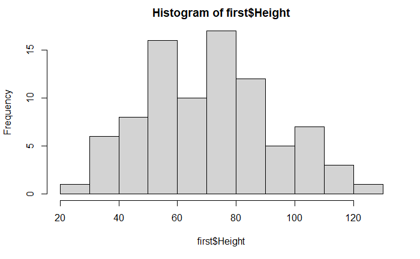

```r
first <- dataframe %>% drop_na() %>% select(c(Height, MaturType, GrowthType)) %>% group_by(MaturType)
second <-  dataframe %>% drop_na() %>% select(c(Height, MaturType, GrowthType))
hist(first$Height)
```

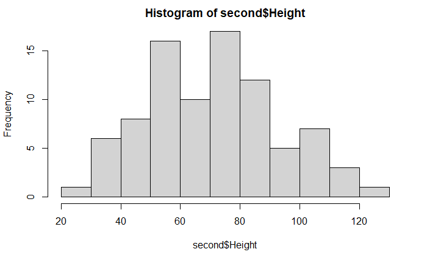

```r
hist(second$Height)
```

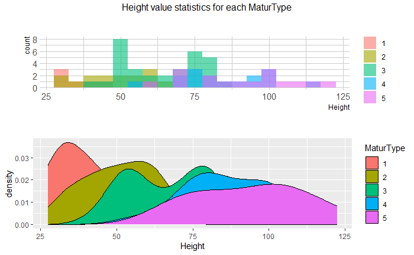

```r
graphic1 <-first %>%
ggplot( aes(x=Height, fill=MaturType)) +
  geom_histogram( position = 'identity', binwidth=5, alpha=0.6) +
  theme_ipsum() +
  labs(fill="")
graphic2 <- first %>%
  ggplot(aes(x=Height, fill=MaturType)) +
  geom_density(aes(Height))
grid.arrange(graphic1, graphic2, nrow=2,top="Height value statistics for each MaturType")
```